# Part I - (Ford GoBike System Data)

## Introduction

> This data set includes information about individual rides made in a bike-sharing system covering the greater San Francisco Bay area. I will explore the dataset to understand the relationships for all data in order, which is gathering cleaning as the Wrangling part then there will be exploration as uni, bi and multi explorations to understand this dataset more

## Preliminary Wrangling

```python
# import all packages and set plots to be embedded inline
import numpy as np
import pandas as pd
import matplotlib.pyplot as plt
import seaborn as sb
import datetime

import warnings
warnings.simplefilter("ignore")


%matplotlib inline
```

```python
df= pd.read_csv("201902-fordgobike-tripdata.csv")
df.head(10)
```

|  | duration_sec | start_time | end_time | start_station_id | start_station_name | start_station_latitude | start_station_longitude | end_station_id | end_station_name | end_station_latitude | end_station_longitude | bike_id | user_type | member_birth_year | member_gender | bike_share_for_all_trip |
| --- | --- | --- | --- | --- | --- | --- | --- | --- | --- | --- | --- | --- | --- | --- | --- | --- |
| 0 | 52185 | 2019-02-28 17:32:10.1450 | 2019-03-01 08:01:55.9750 | 21.0 | Montgomery St BART Station (Market St at 2nd St) | 37.789625 | -122.400811 | 13.0 | Commercial St at Montgomery St | 37.794231 | -122.402923 | 4902 | Customer | 1984.0 | Male | No |
| 1 | 42521 | 2019-02-28 18:53:21.7890 | 2019-03-01 06:42:03.0560 | 23.0 | The Embarcadero at Steuart St | 37.791464 | -122.391034 | 81.0 | Berry St at 4th St | 37.775880 | -122.393170 | 2535 | Customer | NaN | NaN | No |
| 2 | 61854 | 2019-02-28 12:13:13.2180 | 2019-03-01 05:24:08.1460 | 86.0 | Market St at Dolores St | 37.769305 | -122.426826 | 3.0 | Powell St BART Station (Market St at 4th St) | 37.786375 | -122.404904 | 5905 | Customer | 1972.0 | Male | No |
| 3 | 36490 | 2019-02-28 17:54:26.0100 | 2019-03-01 04:02:36.8420 | 375.0 | Grove St at Masonic Ave | 37.774836 | -122.446546 | 70.0 | Central Ave at Fell St | 37.773311 | -122.444293 | 6638 | Subscriber | 1989.0 | Other | No |
| 4 | 1585 | 2019-02-28 23:54:18.5490 | 2019-03-01 00:20:44.0740 | 7.0 | Frank H Ogawa Plaza | 37.804562 | -122.271738 | 222.0 | 10th Ave at E 15th St | 37.792714 | -122.248780 | 4898 | Subscriber | 1974.0 | Male | Yes |
| 5 | 1793 | 2019-02-28 23:49:58.6320 | 2019-03-01 00:19:51.7600 | 93.0 | 4th St at Mission Bay Blvd S | 37.770407 | -122.391198 | 323.0 | Broadway at Kearny | 37.798014 | -122.405950 | 5200 | Subscriber | 1959.0 | Male | No |
| 6 | 1147 | 2019-02-28 23:55:35.1040 | 2019-03-01 00:14:42.5880 | 300.0 | Palm St at Willow St | 37.317298 | -121.884995 | 312.0 | San Jose Diridon Station | 37.329732 | -121.901782 | 3803 | Subscriber | 1983.0 | Female | No |
| 7 | 1615 | 2019-02-28 23:41:06.7660 | 2019-03-01 00:08:02.7560 | 10.0 | Washington St at Kearny St | 37.795393 | -122.404770 | 127.0 | Valencia St at 21st St | 37.756708 | -122.421025 | 6329 | Subscriber | 1989.0 | Male | No |
| 8 | 1570 | 2019-02-28 23:41:48.7900 | 2019-03-01 00:07:59.7150 | 10.0 | Washington St at Kearny St | 37.795393 | -122.404770 | 127.0 | Valencia St at 21st St | 37.756708 | -122.421025 | 6548 | Subscriber | 1988.0 | Other | No |
| 9 | 1049 | 2019-02-28 23:49:47.6990 | 2019-03-01 00:07:17.0250 | 19.0 | Post St at Kearny St | 37.788975 | -122.403452 | 121.0 | Mission Playground | 37.759210 | -122.421339 | 6488 | Subscriber | 1992.0 | Male | No |

```python
df.describe()
```

|  | duration_sec | start_station_id | start_station_latitude | start_station_longitude | end_station_id | end_station_latitude | end_station_longitude | bike_id | member_birth_year |
| --- | --- | --- | --- | --- | --- | --- | --- | --- | --- |
| count | 183412.000000 | 183215.000000 | 183412.000000 | 183412.000000 | 183215.000000 | 183412.000000 | 183412.000000 | 183412.000000 | 175147.000000 |
| mean | 726.078435 | 138.590427 | 37.771223 | -122.352664 | 136.249123 | 37.771427 | -122.352250 | 4472.906375 | 1984.806437 |
| std | 1794.389780 | 111.778864 | 0.099581 | 0.117097 | 111.515131 | 0.099490 | 0.116673 | 1664.383394 | 10.116689 |
| min | 61.000000 | 3.000000 | 37.317298 | -122.453704 | 3.000000 | 37.317298 | -122.453704 | 11.000000 | 1878.000000 |
| 25% | 325.000000 | 47.000000 | 37.770083 | -122.412408 | 44.000000 | 37.770407 | -122.411726 | 3777.000000 | 1980.000000 |
| 50% | 514.000000 | 104.000000 | 37.780760 | -122.398285 | 100.000000 | 37.781010 | -122.398279 | 4958.000000 | 1987.000000 |
| 75% | 796.000000 | 239.000000 | 37.797280 | -122.286533 | 235.000000 | 37.797320 | -122.288045 | 5502.000000 | 1992.000000 |
| max | 85444.000000 | 398.000000 | 37.880222 | -121.874119 | 398.000000 | 37.880222 | -121.874119 | 6645.000000 | 2001.000000 |

```python
df.shape
```

```
(183412, 16)
```

```python
df.info()
```

```
<class 'pandas.core.frame.DataFrame'>
RangeIndex: 183412 entries, 0 to 183411
Data columns (total 16 columns):
 #   Column                   Non-Null Count   Dtype
---  ------                   --------------   -----
 0   duration_sec             183412 non-null  int64
 1   start_time               183412 non-null  object
 2   end_time                 183412 non-null  object
 3   start_station_id         183215 non-null  float64
 4   start_station_name       183215 non-null  object
 5   start_station_latitude   183412 non-null  float64
 6   start_station_longitude  183412 non-null  float64
 7   end_station_id           183215 non-null  float64
 8   end_station_name         183215 non-null  object
 9   end_station_latitude     183412 non-null  float64
 10  end_station_longitude    183412 non-null  float64
 11  bike_id                  183412 non-null  int64
 12  user_type                183412 non-null  object
 13  member_birth_year        175147 non-null  float64
 14  member_gender            175147 non-null  object
 15  bike_share_for_all_trip  183412 non-null  object
dtypes: float64(7), int64(2), object(7)
memory usage: 22.4+ MB
```

- we notice here that there's a wrong data type for some columns like start_time and end_time.
- also we can add column called member age it will be calculated from member_birth_year column.
- The start time composed of a lot of data like months days hours...

```python
df['member_age'] = 2019 - df['member_birth_year']
df.head()
```

|  | duration_sec | start_time | end_time | start_station_id | start_station_name | start_station_latitude | start_station_longitude | end_station_id | end_station_name | end_station_latitude | end_station_longitude | bike_id | user_type | member_birth_year | member_gender | bike_share_for_all_trip | member_age |
| --- | --- | --- | --- | --- | --- | --- | --- | --- | --- | --- | --- | --- | --- | --- | --- | --- | --- |
| 0 | 52185 | 2019-02-28 17:32:10.1450 | 2019-03-01 08:01:55.9750 | 21.0 | Montgomery St BART Station (Market St at 2nd St) | 37.789625 | -122.400811 | 13.0 | Commercial St at Montgomery St | 37.794231 | -122.402923 | 4902 | Customer | 1984.0 | Male | No | 35.0 |
| 1 | 42521 | 2019-02-28 18:53:21.7890 | 2019-03-01 06:42:03.0560 | 23.0 | The Embarcadero at Steuart St | 37.791464 | -122.391034 | 81.0 | Berry St at 4th St | 37.775880 | -122.393170 | 2535 | Customer | NaN | NaN | No | NaN |
| 2 | 61854 | 2019-02-28 12:13:13.2180 | 2019-03-01 05:24:08.1460 | 86.0 | Market St at Dolores St | 37.769305 | -122.426826 | 3.0 | Powell St BART Station (Market St at 4th St) | 37.786375 | -122.404904 | 5905 | Customer | 1972.0 | Male | No | 47.0 |
| 3 | 36490 | 2019-02-28 17:54:26.0100 | 2019-03-01 04:02:36.8420 | 375.0 | Grove St at Masonic Ave | 37.774836 | -122.446546 | 70.0 | Central Ave at Fell St | 37.773311 | -122.444293 | 6638 | Subscriber | 1989.0 | Other | No | 30.0 |
| 4 | 1585 | 2019-02-28 23:54:18.5490 | 2019-03-01 00:20:44.0740 | 7.0 | Frank H Ogawa Plaza | 37.804562 | -122.271738 | 222.0 | 10th Ave at E 15th St | 37.792714 | -122.248780 | 4898 | Subscriber | 1974.0 | Male | Yes | 45.0 |

```python
df['duration_min'] = df['duration_sec'] / 60
df.head()
```

|  | duration_sec | start_time | end_time | start_station_id | start_station_name | start_station_latitude | start_station_longitude | end_station_id | end_station_name | end_station_latitude | end_station_longitude | bike_id | user_type | member_birth_year | member_gender | bike_share_for_all_trip | member_age | duration_min |
| --- | --- | --- | --- | --- | --- | --- | --- | --- | --- | --- | --- | --- | --- | --- | --- | --- | --- | --- |
| 0 | 52185 | 2019-02-28 17:32:10.1450 | 2019-03-01 08:01:55.9750 | 21.0 | Montgomery St BART Station (Market St at 2nd St) | 37.789625 | -122.400811 | 13.0 | Commercial St at Montgomery St | 37.794231 | -122.402923 | 4902 | Customer | 1984.0 | Male | No | 35.0 | 869.750000 |
| 1 | 42521 | 2019-02-28 18:53:21.7890 | 2019-03-01 06:42:03.0560 | 23.0 | The Embarcadero at Steuart St | 37.791464 | -122.391034 | 81.0 | Berry St at 4th St | 37.775880 | -122.393170 | 2535 | Customer | NaN | NaN | No | NaN | 708.683333 |
| 2 | 61854 | 2019-02-28 12:13:13.2180 | 2019-03-01 05:24:08.1460 | 86.0 | Market St at Dolores St | 37.769305 | -122.426826 | 3.0 | Powell St BART Station (Market St at 4th St) | 37.786375 | -122.404904 | 5905 | Customer | 1972.0 | Male | No | 47.0 | 1030.900000 |
| 3 | 36490 | 2019-02-28 17:54:26.0100 | 2019-03-01 04:02:36.8420 | 375.0 | Grove St at Masonic Ave | 37.774836 | -122.446546 | 70.0 | Central Ave at Fell St | 37.773311 | -122.444293 | 6638 | Subscriber | 1989.0 | Other | No | 30.0 | 608.166667 |
| 4 | 1585 | 2019-02-28 23:54:18.5490 | 2019-03-01 00:20:44.0740 | 7.0 | Frank H Ogawa Plaza | 37.804562 | -122.271738 | 222.0 | 10th Ave at E 15th St | 37.792714 | -122.248780 | 4898 | Subscriber | 1974.0 | Male | Yes | 45.0 | 26.416667 |

```python
df['duration_hours'] = df['duration_min'] / 60
df.head()
```

|  | duration_sec | start_time | end_time | start_station_id | start_station_name | start_station_latitude | start_station_longitude | end_station_id | end_station_name | end_station_latitude | end_station_longitude | bike_id | user_type | member_birth_year | member_gender | bike_share_for_all_trip | member_age | duration_min | duration_hours |
| --- | --- | --- | --- | --- | --- | --- | --- | --- | --- | --- | --- | --- | --- | --- | --- | --- | --- | --- | --- |
| 0 | 52185 | 2019-02-28 17:32:10.1450 | 2019-03-01 08:01:55.9750 | 21.0 | Montgomery St BART Station (Market St at 2nd St) | 37.789625 | -122.400811 | 13.0 | Commercial St at Montgomery St | 37.794231 | -122.402923 | 4902 | Customer | 1984.0 | Male | No | 35.0 | 869.750000 | 14.495833 |
| 1 | 42521 | 2019-02-28 18:53:21.7890 | 2019-03-01 06:42:03.0560 | 23.0 | The Embarcadero at Steuart St | 37.791464 | -122.391034 | 81.0 | Berry St at 4th St | 37.775880 | -122.393170 | 2535 | Customer | NaN | NaN | No | NaN | 708.683333 | 11.811389 |
| 2 | 61854 | 2019-02-28 12:13:13.2180 | 2019-03-01 05:24:08.1460 | 86.0 | Market St at Dolores St | 37.769305 | -122.426826 | 3.0 | Powell St BART Station (Market St at 4th St) | 37.786375 | -122.404904 | 5905 | Customer | 1972.0 | Male | No | 47.0 | 1030.900000 | 17.181667 |
| 3 | 36490 | 2019-02-28 17:54:26.0100 | 2019-03-01 04:02:36.8420 | 375.0 | Grove St at Masonic Ave | 37.774836 | -122.446546 | 70.0 | Central Ave at Fell St | 37.773311 | -122.444293 | 6638 | Subscriber | 1989.0 | Other | No | 30.0 | 608.166667 | 10.136111 |
| 4 | 1585 | 2019-02-28 23:54:18.5490 | 2019-03-01 00:20:44.0740 | 7.0 | Frank H Ogawa Plaza | 37.804562 | -122.271738 | 222.0 | 10th Ave at E 15th St | 37.792714 | -122.248780 | 4898 | Subscriber | 1974.0 | Male | Yes | 45.0 | 26.416667 | 0.440278 |

```python
df.start_time = pd.to_datetime(df.start_time)
df.end_time = pd.to_datetime(df.end_time)
# source https://towardsdatascience.com/converting-data-to-a-numeric-type-in-pandas-db9415caab0b
#df['member_birth_year'] = df['member_birth_year'] = pd.to_numeric(df['member_birth_year'], errors='coerce').fillna(0).astype('int')
#df['member_age'] =  df['member_age'] = pd.to_numeric(df['member_age'], errors='coerce').fillna(0).astype('int')
```

```python
#extract a lot of data from start time column
df['start_date'] = df.start_time.dt.strftime('%Y-%m-%d')
df['start_hours'] = df.start_time.dt.strftime('%H')
df['start_days'] = df.start_time.dt.strftime('%A')
df['start_month'] = df.start_time.dt.strftime('%B')
```

```python
df.head()
```

|  | duration_sec | start_time | end_time | start_station_id | start_station_name | start_station_latitude | start_station_longitude | end_station_id | end_station_name | end_station_latitude | ... | member_birth_year | member_gender | bike_share_for_all_trip | member_age | duration_min | duration_hours | start_date | start_hours | start_days | start_month |
| --- | --- | --- | --- | --- | --- | --- | --- | --- | --- | --- | --- | --- | --- | --- | --- | --- | --- | --- | --- | --- | --- |
| 0 | 52185 | 2019-02-28 17:32:10.145 | 2019-03-01 08:01:55.975 | 21.0 | Montgomery St BART Station (Market St at 2nd St) | 37.789625 | -122.400811 | 13.0 | Commercial St at Montgomery St | 37.794231 | ... | 1984.0 | Male | No | 35.0 | 869.750000 | 14.495833 | 2019-02-28 | 17 | Thursday | February |
| 1 | 42521 | 2019-02-28 18:53:21.789 | 2019-03-01 06:42:03.056 | 23.0 | The Embarcadero at Steuart St | 37.791464 | -122.391034 | 81.0 | Berry St at 4th St | 37.775880 | ... | NaN | NaN | No | NaN | 708.683333 | 11.811389 | 2019-02-28 | 18 | Thursday | February |
| 2 | 61854 | 2019-02-28 12:13:13.218 | 2019-03-01 05:24:08.146 | 86.0 | Market St at Dolores St | 37.769305 | -122.426826 | 3.0 | Powell St BART Station (Market St at 4th St) | 37.786375 | ... | 1972.0 | Male | No | 47.0 | 1030.900000 | 17.181667 | 2019-02-28 | 12 | Thursday | February |
| 3 | 36490 | 2019-02-28 17:54:26.010 | 2019-03-01 04:02:36.842 | 375.0 | Grove St at Masonic Ave | 37.774836 | -122.446546 | 70.0 | Central Ave at Fell St | 37.773311 | ... | 1989.0 | Other | No | 30.0 | 608.166667 | 10.136111 | 2019-02-28 | 17 | Thursday | February |
| 4 | 1585 | 2019-02-28 23:54:18.549 | 2019-03-01 00:20:44.074 | 7.0 | Frank H Ogawa Plaza | 37.804562 | -122.271738 | 222.0 | 10th Ave at E 15th St | 37.792714 | ... | 1974.0 | Male | Yes | 45.0 | 26.416667 | 0.440278 | 2019-02-28 | 23 | Thursday | February |

5 rows × 23 columns

```python
df.info()
```

```
<class 'pandas.core.frame.DataFrame'>
RangeIndex: 183412 entries, 0 to 183411
Data columns (total 23 columns):
 #   Column                   Non-Null Count   Dtype
---  ------                   --------------   -----
 0   duration_sec             183412 non-null  int64
 1   start_time               183412 non-null  datetime64[ns]
 2   end_time                 183412 non-null  datetime64[ns]
 3   start_station_id         183215 non-null  float64
 4   start_station_name       183215 non-null  object
 5   start_station_latitude   183412 non-null  float64
 6   start_station_longitude  183412 non-null  float64
 7   end_station_id           183215 non-null  float64
 8   end_station_name         183215 non-null  object
 9   end_station_latitude     183412 non-null  float64
 10  end_station_longitude    183412 non-null  float64
 11  bike_id                  183412 non-null  int64
 12  user_type                183412 non-null  object
 13  member_birth_year        175147 non-null  float64
 14  member_gender            175147 non-null  object
 15  bike_share_for_all_trip  183412 non-null  object
 16  member_age               175147 non-null  float64
 17  duration_min             183412 non-null  float64
 18  duration_hours           183412 non-null  float64
 19  start_date               183412 non-null  object
 20  start_hours              183412 non-null  object
 21  start_days               183412 non-null  object
 22  start_month              183412 non-null  object
dtypes: datetime64[ns](2), float64(10), int64(2), object(9)
memory usage: 32.2+ MB
```

```python
df.duplicated().sum()
```

```
0
```

```python
df.member_gender.value_counts()
```

```
Male      130651
Female     40844
Other       3652
Name: member_gender, dtype: int64
```

```python
df.bike_share_for_all_trip.value_counts()
```

```
No     166053
Yes     17359
Name: bike_share_for_all_trip, dtype: int64
```

```python
df.user_type.value_counts()
```

```
Subscriber    163544
Customer       19868
Name: user_type, dtype: int64
```

```python
df.head()
```

|  | duration_sec | start_time | end_time | start_station_id | start_station_name | start_station_latitude | start_station_longitude | end_station_id | end_station_name | end_station_latitude | ... | member_birth_year | member_gender | bike_share_for_all_trip | member_age | duration_min | duration_hours | start_date | start_hours | start_days | start_month |
| --- | --- | --- | --- | --- | --- | --- | --- | --- | --- | --- | --- | --- | --- | --- | --- | --- | --- | --- | --- | --- | --- |
| 0 | 52185 | 2019-02-28 17:32:10.145 | 2019-03-01 08:01:55.975 | 21.0 | Montgomery St BART Station (Market St at 2nd St) | 37.789625 | -122.400811 | 13.0 | Commercial St at Montgomery St | 37.794231 | ... | 1984.0 | Male | No | 35.0 | 869.750000 | 14.495833 | 2019-02-28 | 17 | Thursday | February |
| 1 | 42521 | 2019-02-28 18:53:21.789 | 2019-03-01 06:42:03.056 | 23.0 | The Embarcadero at Steuart St | 37.791464 | -122.391034 | 81.0 | Berry St at 4th St | 37.775880 | ... | NaN | NaN | No | NaN | 708.683333 | 11.811389 | 2019-02-28 | 18 | Thursday | February |
| 2 | 61854 | 2019-02-28 12:13:13.218 | 2019-03-01 05:24:08.146 | 86.0 | Market St at Dolores St | 37.769305 | -122.426826 | 3.0 | Powell St BART Station (Market St at 4th St) | 37.786375 | ... | 1972.0 | Male | No | 47.0 | 1030.900000 | 17.181667 | 2019-02-28 | 12 | Thursday | February |
| 3 | 36490 | 2019-02-28 17:54:26.010 | 2019-03-01 04:02:36.842 | 375.0 | Grove St at Masonic Ave | 37.774836 | -122.446546 | 70.0 | Central Ave at Fell St | 37.773311 | ... | 1989.0 | Other | No | 30.0 | 608.166667 | 10.136111 | 2019-02-28 | 17 | Thursday | February |
| 4 | 1585 | 2019-02-28 23:54:18.549 | 2019-03-01 00:20:44.074 | 7.0 | Frank H Ogawa Plaza | 37.804562 | -122.271738 | 222.0 | 10th Ave at E 15th St | 37.792714 | ... | 1974.0 | Male | Yes | 45.0 | 26.416667 | 0.440278 | 2019-02-28 | 23 | Thursday | February |

5 rows × 23 columns

```python
df.member_age.mean()
```

```
34.19356312126385
```

### What is the structure of your dataset?

> The dataset are composed of 16 columns and other columns have been added later to the dataset which is member age, durations in minuts and duration in hours...etc , also the data set contains 183412 rows for the dataset, also with a different variable types like int, float, string and date time format.

### What is/are the main feature(s) of interest in your dataset?

> My interest for the dataset for the duration like the start and the end also the duration in second, minutes and hours. Also user type and other member information like age and gender.

### What features in the dataset do you think will help support your investigation into your feature(s) of interest?

> I think the start time also the durations, user type, age and gender, and bike share status for all trip

## Univariate Exploration

```python
def Xcountplot(figsiz,axs,data_df,xdata,rot,tit,xl,yl):
    base_color = sb.color_palette()[0]
    fig = plt.figure(figsize=(figsiz[0], figsiz[1]))
    ax = fig.add_axes(axs)
    sb.countplot(data = data_df, x = xdata, color=base_color);
    plt.xticks(rotation=rot);
    plt.title(tit, y=1.05, fontsize=15)
    plt.xlabel(xl, labelpad=15)
    plt.ylabel(yl, labelpad=15)
```

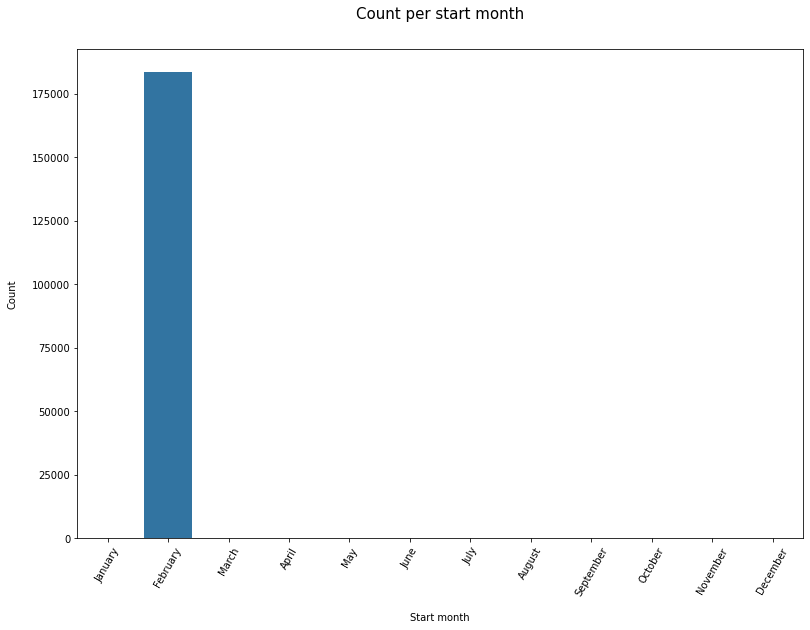

```python
months = ['January', 'February', 'March', 'April', 'May', 'June', 'July', 'August', 'September', 'October', 'November', 'December']
Xmonths = pd.api.types.CategoricalDtype(ordered = True, categories = months)
df.start_month = df.start_month.astype(Xmonths)

Xcountplot([13,9],[.125, .125, .775, .755],df,'start_month',60,'Count per start month', 'Start month', 'Count')
```

> as we noticed that the start month of the trip are all at the same month which is feb and that was surprising

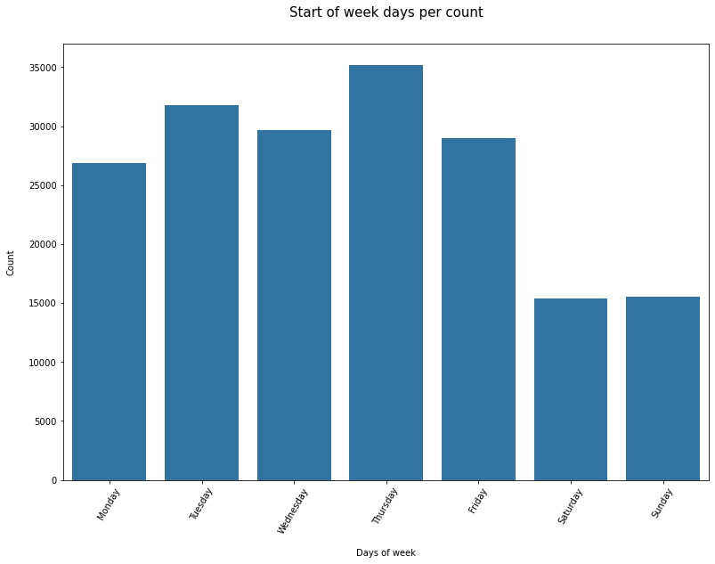

```python
days = ['Monday', 'Tuesday', 'Wednesday', 'Thursday', 'Friday', 'Saturday', 'Sunday']
Xdays = pd.api.types.CategoricalDtype(ordered = True, categories = days)
df.start_days = df.start_days.astype(Xdays)

Xcountplot([13,9],[.125, .125, .775, .755],df,'start_days',60,'Start of week days per count','Days of week', 'Count')
```

> as we noticed here that the weekdays have a higher trip number than the weekend days which proves that a lot of people use it for work or school purposes

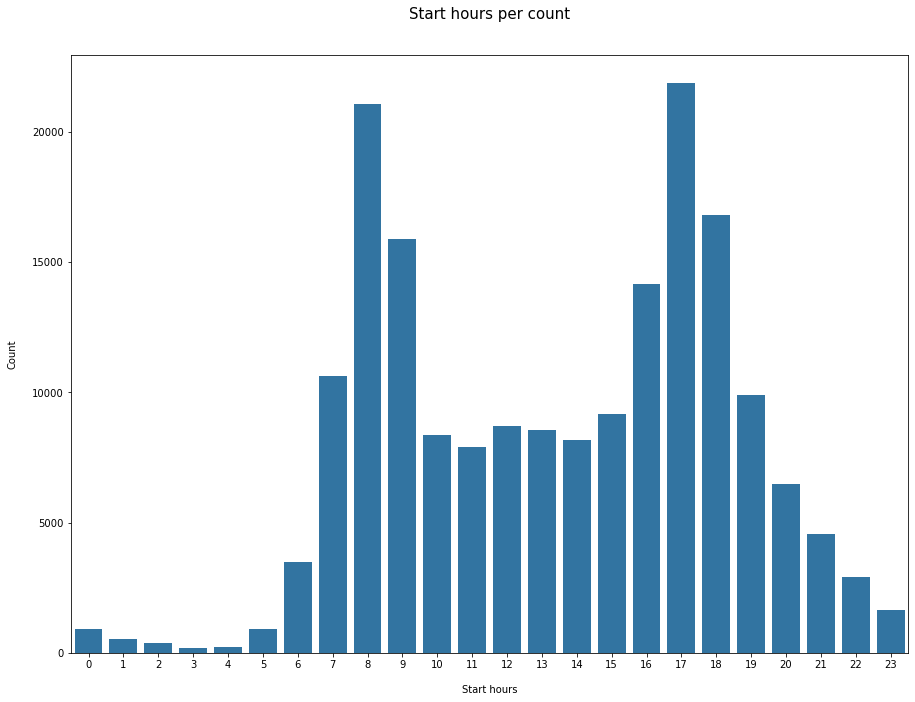

```python
df.start_hours = df.start_hours.astype('int')
Xcountplot([15,11],[.125, .125, .775, .755],df,'start_hours',0,'Start hours per count','Start hours','Count')
```

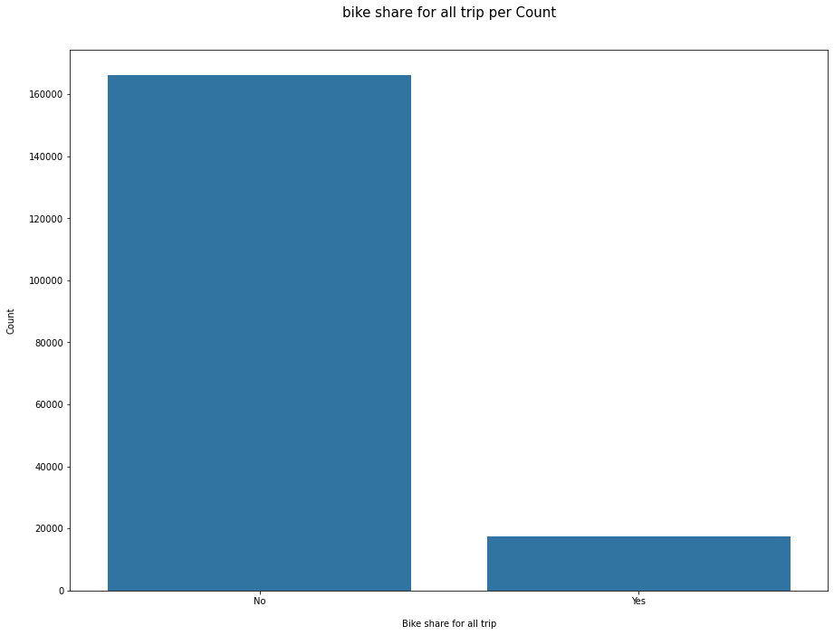

```python
Xcountplot([15,11],[.125, .125, .775, .755],df,'bike_share_for_all_trip',0,'bike share for all trip per Count','Bike share for all trip',"Count")
```

> number of no are way more than yes as we noticed

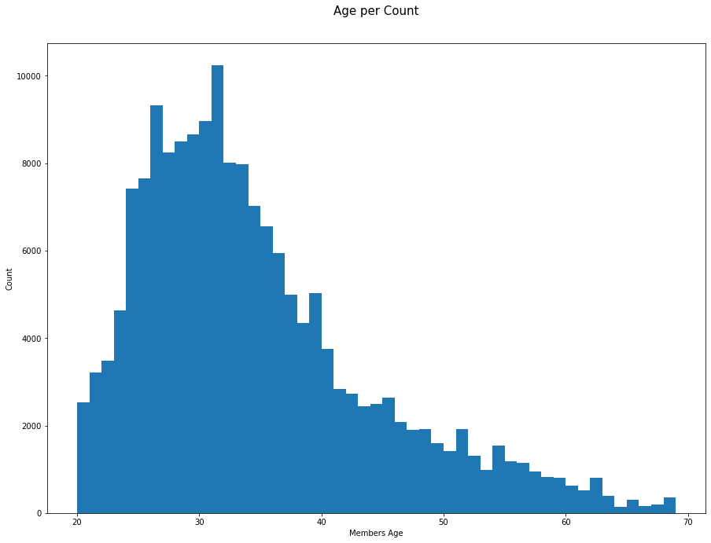

```python
Xbin = np.arange(20, 70, 1)
fig = plt.figure(figsize=(15, 11))
plt.hist(data = df, x = 'member_age', bins = Xbin);

plt.title("Age per Count", y=1.05, fontsize=15)
plt.xlabel('Members Age')
plt.ylabel('Count');
```

> it seems people in their thirties are the most taken tripes than the earliest twenties or the olders

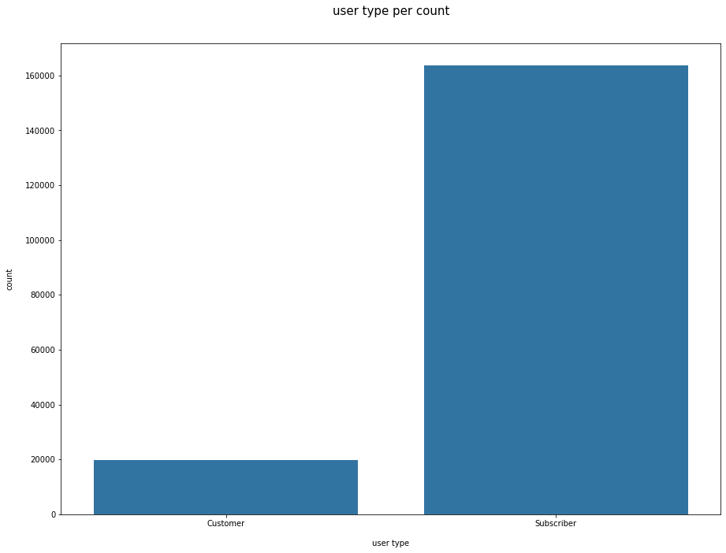

```python
Xcountplot([15,11],[.125, .125, .775, .755],df,'user_type',0,'user type per count','user type','count')
```

> the Subscribers are way more than the customers

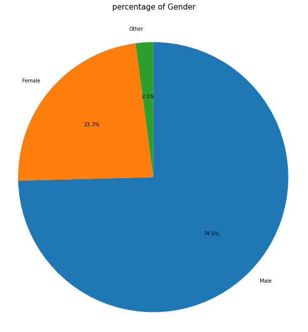

```python
gender_counts = df['member_gender'].value_counts()
fig = plt.figure(figsize=(15, 11))

plt.pie(gender_counts, labels = gender_counts.index, startangle = 90,autopct= '%1.1f%%', counterclock = False);

plt.axis('square')
plt.title("percentage of Gender", y=1.05, fontsize=15)
```

> the percentage of males that use the service is more than the other genders with almost 75%, then female members with 23% as second after that the others with only 2% which is the lowest

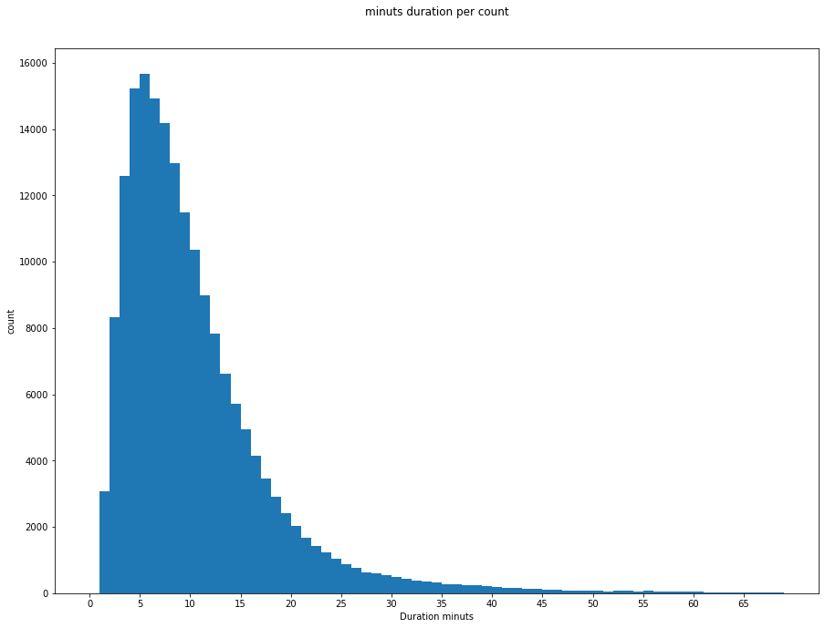

```python
bin_edges = np.arange(0, 70, 1)
fig = plt.figure(figsize=(15, 11))
plt.hist(data = df, x = 'duration_min', bins = bin_edges);
tick = np.arange(0, 70, 5)
plt.title("minuts duration per count", y=1.05)
plt.xticks(tick, tick);
plt.xlabel('Duration minuts')
plt.ylabel('count');
```

> people using the service for short durations in minuts

### Of the features you investigated, were there any unusual distributions? Did you perform any operations on the data to tidy, adjust, or change the form of the data? If so, why did you do this?

> The distribution of the date of the service are all in Feb month which was surprising, also most of the people using the service for a short duration in minutes

## Bivariate Exploration

```python
def countplot(df,x1,h,tit,xl,yl):
    plt.figure(figsize=(15,9))
    sb.countplot(data = df, x = x1, hue = h)
    plt.title(tit, fontsize=22, y=1.015)
    plt.xlabel(xl, labelpad=16)
    plt.ylabel(yl, labelpad=16)
```

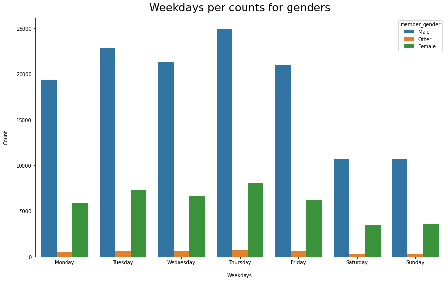

```python
 countplot(df, 'start_days', 'member_gender', 'Weekdays per counts for genders', 'Weekdays', 'Count')
```

> we can see here that all genders prefer using the service on Thursday compared to the other days

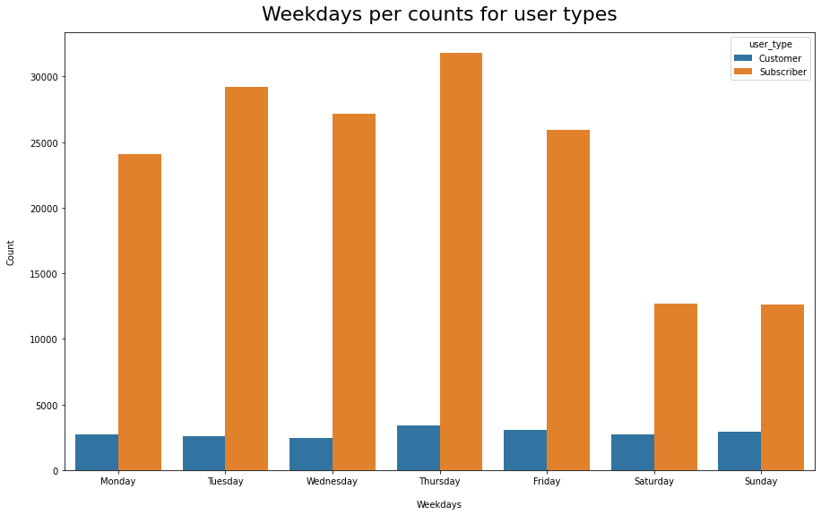

```python
countplot(df, 'start_days', 'user_type', 'Weekdays per counts for user types', 'Weekdays', 'Count')
```

> We can notice the difference between both of the user types, but we can see that both of the user types increase for Thursday, unlike Subscriber which increases on the weekdays and decreases at the weekend, the Customer has kind of stable rate for all days

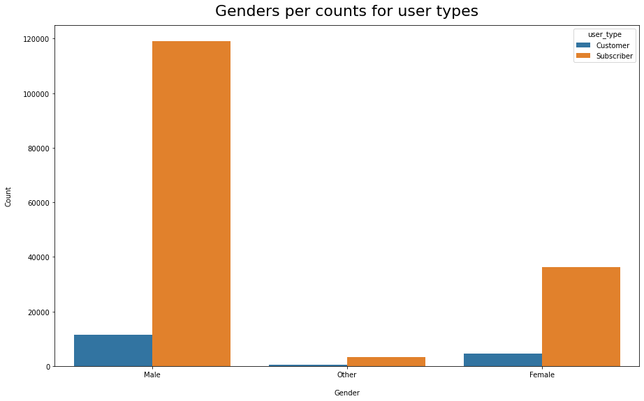

```python
countplot(df, 'member_gender', 'user_type', 'Genders per counts for user types', 'Gender', 'Count')
```

> We can noticed that all genders prefer Subscriber as user type.

[figure not shown]

```python
countplot(df, 'user_type', 'bike_share_for_all_trip', 'Genders per counts for bike_share_for_all_trip', 'Gender', 'Count')
```

> We noticed that all user type dont prefer sharing bike for all trip.

[figure not shown]

```python
countplot(df, 'member_gender', 'bike_share_for_all_trip', 'User type per counts for bike_share_for_all_trip', 'User type', 'Count')
```

> We noticed that all genders dont prefer sharing bike for all trip

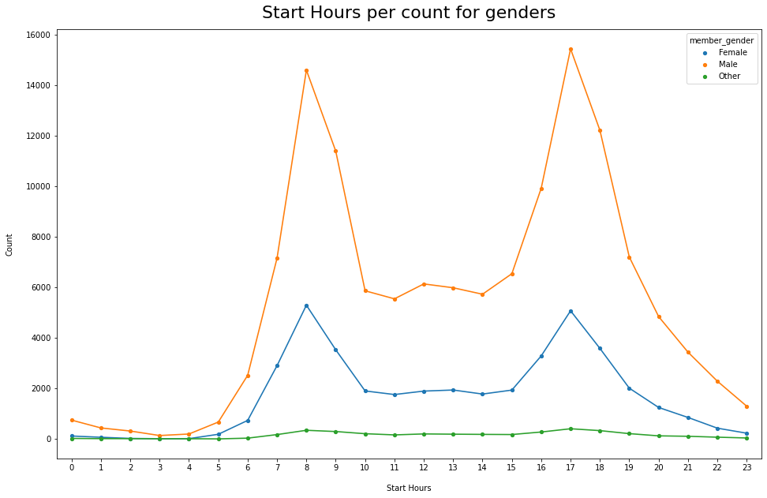

```python
subscriber_age = df[df['bike_id']!=0].groupby(['start_hours', 'member_gender']).agg({'bike_id':'count'}).reset_index()

plt.figure(figsize=(16,10))
sb.pointplot(x='start_hours', y='bike_id', hue='member_gender', scale=.6, data=subscriber_age)
plt.title("Start Hours per count for genders", fontsize=22, y=1.015)
plt.xlabel('Start Hours', labelpad=16)
plt.ylabel('Count', labelpad=16)
```

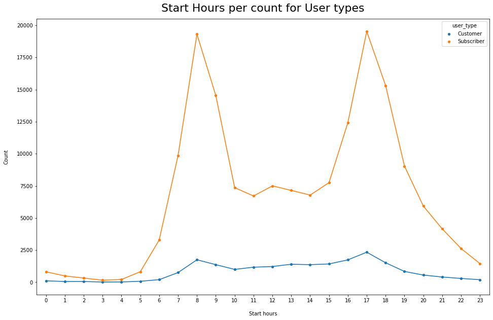

```python
subscriber_age = df[df['bike_id']!=0].groupby(['start_hours', 'user_type']).agg({'bike_id':'count'}).reset_index()

plt.figure(figsize=(16,10))
sb.pointplot(x='start_hours', y='bike_id', hue='user_type', scale=.6, data=subscriber_age)
plt.title("Start Hours per count for User types", fontsize=22, y=1.015)
plt.xlabel('Start hours', labelpad=16)
plt.ylabel('Count', labelpad=16)
```

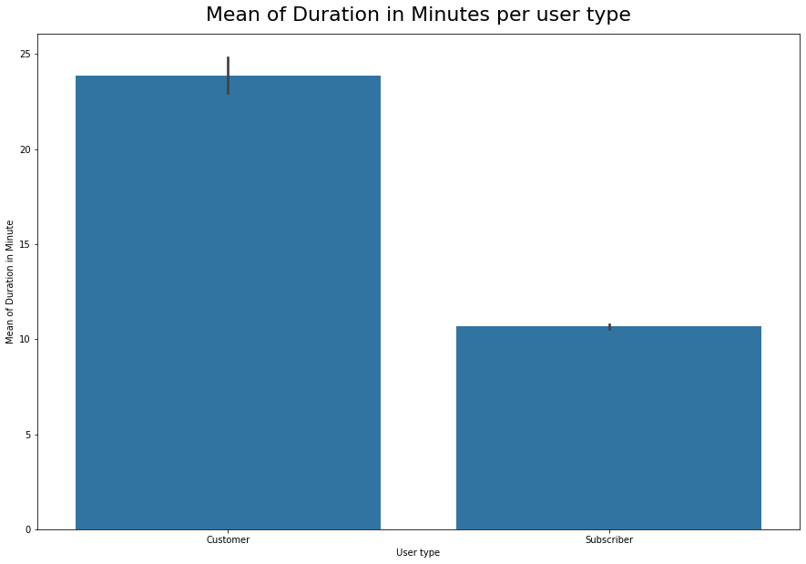

```python
plt.figure(figsize=(15,10))
base_color = sb.color_palette()[0]
sb.barplot(data=df, x='user_type', y='duration_min', color=base_color);
plt.title("Mean of Duration in Minutes per user type", fontsize=22, y=1.015)
plt.xlabel('User type');
plt.ylabel('Mean of Duration in Minute');
```

> We can see here the mean duration in minutes of customer are higher than the subscriber even though it has the least number, and this tills that customer use the service with more duration than subscriber

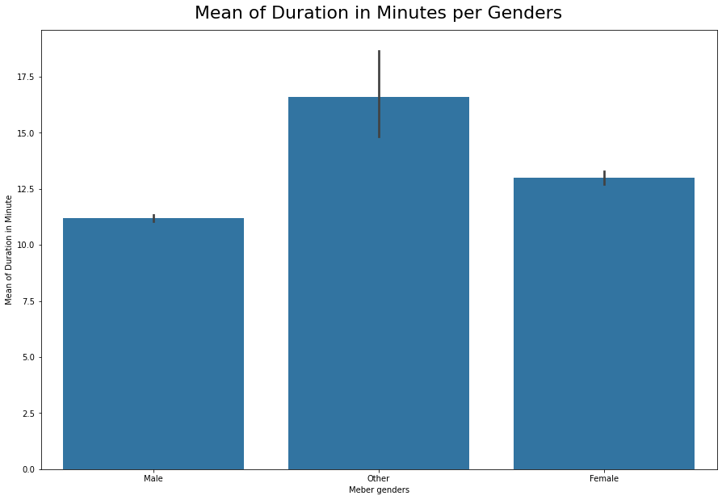

```python
plt.figure(figsize=(15,10))
base_color = sb.color_palette()[0]
sb.barplot(data=df, x='member_gender', y='duration_min', color=base_color);
plt.title("Mean of Duration in Minutes per Genders", fontsize=22, y=1.015)
plt.xlabel('Meber genders');
plt.ylabel('Mean of Duration in Minute');
```

> We can see here the mean duration in minutes of others are higher than the females and males

### Did you observe any interesting relationships between the other features (not the main feature(s) of interest)?

> Yes, the relationship between the mean of minutes duration and user type, it was kind of surprising to see the customers spent more duration than subscribers even though the number of subscribers is more than the customers and that will show that the customers like to use the service for more duration of time. Also the same thing to genders it shows that Others like to use the service for a longer duration than females and males after each other with few gaps and that was surprising because the number of males is higher than the other genders with 75% and it shows that males using the service more with shorter time than other genders.

## Multivariate Exploration

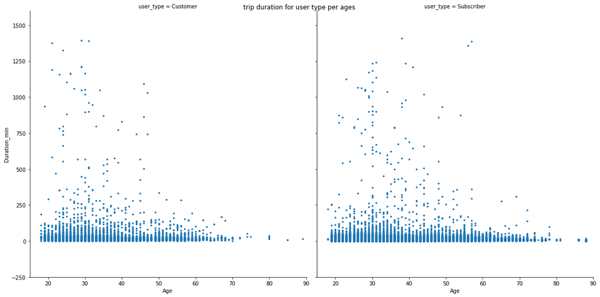

```python
user_type = sb.FacetGrid(data = df, col = 'user_type', col_wrap =2, size = 8,
                 xlim = [15, 90], ylim = [-250, 1600])
user_type.map(plt.scatter, 'member_age', 'duration_min', alpha= 1, s=6)

user_type.set_xlabels('Age')
user_type.set_ylabels('Duration_min')
user_type.fig.suptitle('trip duration for user type per ages ')
```

[output not shown]

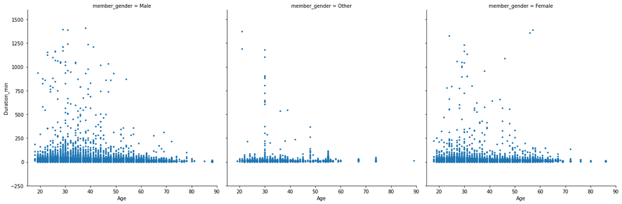

```python
print("trip duration for user type per ages")

user_type = sb.FacetGrid(data = df, col = 'member_gender', col_wrap =3, size = 6,
                 xlim = [15, 90], ylim = [-250, 1600])
user_type.map(plt.scatter, 'member_age', 'duration_min', alpha= 1, s=6)

#user_type.fig.suptitle('trip duration for user type per ages')


user_type.set_xlabels('Age')
user_type.set_ylabels('Duration_min')
```

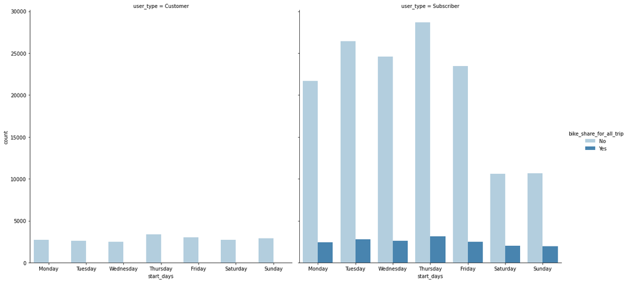

```python
plt.figure(figsize=(15,10))
sb.catplot(x = 'start_days', hue = 'bike_share_for_all_trip', col = 'user_type',
            data = df, kind = 'count', palette = 'Blues', col_wrap = 2,height=8, aspect=1);
```

> We can notice that customers don't prefer bike share for all the trip unlike the subscribers which they do in a reasnoable number

### Talk about some of the relationships you observed in this part of the investigation. Were there features that strengthened each other in terms of looking at your feature(s) of interest?

> The relation between the user age and the duration in minutes for user types was really close to each other that both the customer and the subscribers rude the bike for longer duration at the younger ages between 25 to 40 and less duration than the older people but the difference is the subscriber's ride bikes for more durations at the older ages between 50 and 80 and that's might be because of two factors that the number of subscribers is more than the customers also we saw that customers ride bikes for a longer duration than the subscribers, probably because old people prefer to be subscribers than customers.

### Were there any interesting or surprising interactions between features?

> There weren't any surprising results probably because the previous sections make the previous relationship really clear

## Conclusions

> I explored the dataset to understand the relationships for all data in order, which is gathering, cleaning, and assessing as the wrangling part, I managed to add a lot of columns that have extracted like member age from the member date of birth and from duration in second I managed to add more columns like duration in hours and in minutes also from the start date I managed to extract the month which was later all data at the same month also the start day of weeks and the start hours of the day. After this was the univariate exploration part which is to explore the relationship for one column which was rich knowledge and helpful for the next parts. Then the Bivariate exploration part is the part where you find the relationship between two columns which is the part that I worked on the most because it's a really important part. For last there was the multivariate part which is the part where I explore the relationship between more than one or two, for this part the relationship was clear and it was making sense because of the previous part and that comes to me that all of these parts of exploration are important to make everything clear for the next part of the exploration.